# Residuals in Simple Linear Regression

R Tutorial Notes

This file builds two tiny examples from `openintro::births14`:

1. A 5-row example where residual quartiles from `summary(lm(...))` land exactly on observed points.
2. A 6-row example where quartiles are interpolated.

The workflow is:

- filter to preemies,
- convert birth weight from lbs to kg,
- `slice_tail()` to make the dataset intentionally small,
- fit `birth_wt_kg ~ weeks`,
- hand-compute residuals as `y - ŷ`,
- compare the residual summary (`Min`, `1Q`, `Median`, `3Q`, `Max`),
- connect this to residual standard error.

```r
preemies <- openintro::births14 %>%
  filter(premie == "premie") %>%
  mutate(
    birth_wt_kg = weight * 0.45359237,
    obs_id = row_number()
  )

exact_data <- preemies %>% tail(5)
interp_data <- preemies %>% tail(6)
```

```r
exact_fit <- lm(birth_wt_kg ~ weeks, data = exact_data)
exact_data <- exact_data %>%
  mutate(
    yhat = predict(exact_fit, newdata = exact_data),
    residual = birth_wt_kg - yhat,
    abs_residual = abs(residual),
    squared_residual = residual^2
  )

exact_summary <- summary(exact_fit)$coefficients
exact_resid_summary <- summary(exact_data$residual)
exact_quartiles <- quantile(exact_data$residual, probs = c(0, 0.25, 0.5, 0.75, 1), type = 7)

exact_resid_sorted <- exact_data %>% arrange(residual) %>%
  mutate(quartile_role = c("min", "Q1", "Median", "Q3", "max"))

cat("EXACT 5-ROW EXAMPLE (tail of preemies)\n")
```

```
## EXACT 5-ROW EXAMPLE (tail of preemies)
```

```r
cat("Formula: y = intercept + slope * weeks\n")
```

```
## Formula: y = intercept + slope * weeks
```

```r
cat(sprintf("y = %.6f + %.6f*weeks\n", exact_fit$coefficients[[1]], exact_fit$coefficients[[2]]))
```

```
## y = -14.315051 + 0.489556*weeks
```

```r
cat(sprintf("n = %d\n\n", nrow(exact_data)))
```

```
## n = 5
```

```r
cat("obs_id,weeks,weight_lb,weight_kg,y_hat,actual_minus_fitted\n")
```

```
## obs_id,weeks,weight_lb,weight_kg,y_hat,actual_minus_fitted
```

```r
for (i in seq_len(nrow(exact_data))) {
  cat(sprintf(
    "%d,%d,%.2f,%.4f,%.4f,%.4f\n",
    exact_data$obs_id[i],
    exact_data$weeks[i],
    exact_data$weight[i],
    exact_data$birth_wt_kg[i],
    exact_data$yhat[i],
    exact_data$residual[i]
  ))
}
```

```
## 120,36,8.44,3.8283,3.3090,0.5194
## 121,35,5.58,2.5310,2.8194,-0.2884
## 122,36,5.82,2.6399,3.3090,-0.6690
## 123,32,2.33,1.0569,1.3507,-0.2939
## 124,34,6.75,3.0617,2.3298,0.7319
```

```r
cat("\nresidual summary from R (exact 5-point fit)\n")
```

```
##
## residual summary from R (exact 5-point fit)
```

```r
cat(capture.output(exact_resid_summary), sep = "\n")
```

```
##    Min. 1st Qu.  Median    Mean 3rd Qu.    Max.
## -0.6690 -0.2939 -0.2884  0.0000  0.5194  0.7319
```

```r
cat("\nquantiles extracted directly from quantile(..., type = 7)\n")
```

```
##
## quantiles extracted directly from quantile(..., type = 7)
```

```r
cat(sprintf("Min: %0.4f\n", exact_quartiles[[1]]))
```

```
## Min: -0.6690
```

```r
cat(sprintf("1Q: %0.4f\n", exact_quartiles[[2]]))
```

```
## 1Q: -0.2939
```

```r
cat(sprintf("Median: %0.4f\n", exact_quartiles[[3]]))
```

```
## Median: -0.2884
```

```r
cat(sprintf("3Q: %0.4f\n", exact_quartiles[[4]]))
```

```
## 3Q: 0.5194
```

```r
cat(sprintf("Max: %0.4f\n\n", exact_quartiles[[5]]))
```

```
## Max: 0.7319
```

```r
kable(
  exact_data %>%
    select(obs_id, weeks, birth_wt_kg, yhat, residual) %>%
    mutate(
      hand_math = sprintf("%.4f - %.4f = %.4f", birth_wt_kg, yhat, residual)
    ),
  caption = "Exact 5-row example: exact hand computation y - ŷ = residual",
  digits = 4
)
```

Exact 5-row example: exact hand computation y - ŷ = residual

| obs_id | weeks | birth_wt_kg | yhat | residual | hand_math |
| --- | --- | --- | --- | --- | --- |
| 120 | 36 | 3.8283 | 3.3090 | 0.5194 | 3.8283 - 3.3090 = 0.5194 |
| 121 | 35 | 2.5310 | 2.8194 | -0.2884 | 2.5310 - 2.8194 = -0.2884 |
| 122 | 36 | 2.6399 | 3.3090 | -0.6690 | 2.6399 - 3.3090 = -0.6690 |
| 123 | 32 | 1.0569 | 1.3507 | -0.2939 | 1.0569 - 1.3507 = -0.2939 |
| 124 | 34 | 3.0617 | 2.3298 | 0.7319 | 3.0617 - 2.3298 = 0.7319 |

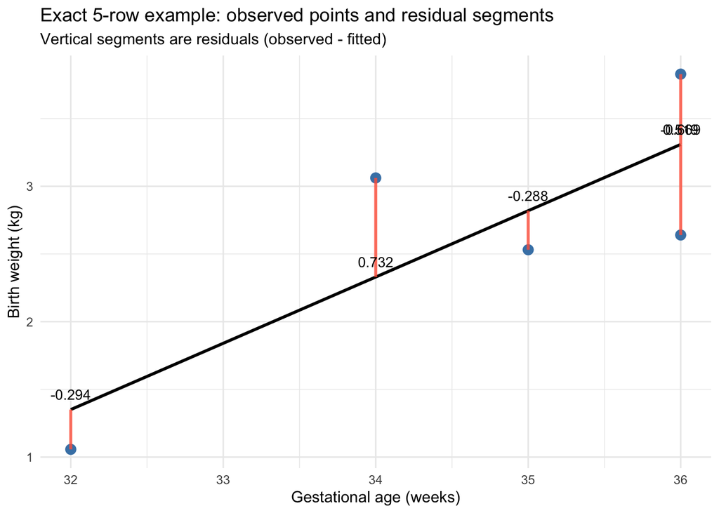

```r
ggplot(exact_data, aes(weeks, birth_wt_kg)) +
  geom_point(size = 3, color = "steelblue") +
  geom_smooth(method = "lm", se = FALSE, linewidth = 1, color = "black") +
  geom_segment(aes(xend = weeks, yend = yhat), alpha = 0.8, linewidth = 1, color = "tomato") +
  geom_text(
    aes(label = round(residual, 3), y = yhat),
    vjust = -1,
    size = 3.5
  ) +
  theme_minimal() +
  labs(
    title = "Exact 5-row example: observed points and residual segments",
    x = "Gestational age (weeks)",
    y = "Birth weight (kg)",
    subtitle = "Vertical segments are residuals (observed - fitted)"
  )
```

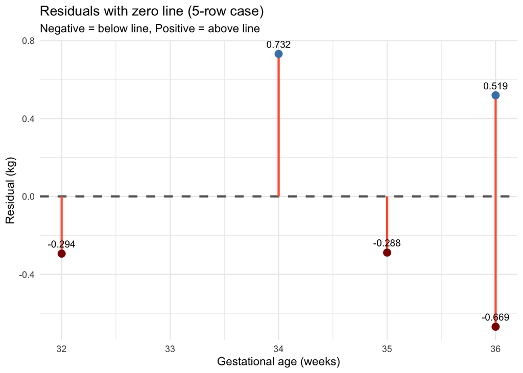

```r
ggplot(exact_data, aes(weeks, residual)) +
  geom_hline(yintercept = 0, linetype = "dashed", linewidth = 1, color = "gray40") +
  geom_segment(aes(xend = weeks, y = 0, yend = residual), linewidth = 1, color = "tomato") +
  geom_point(aes(color = residual > 0), size = 3) +
  geom_text(aes(label = round(residual, 3)), vjust = -0.9, size = 3.3) +
  scale_color_manual(values = c("TRUE" = "steelblue", "FALSE" = "darkred"), guide = "none") +
  theme_minimal() +
  labs(
    title = "Residuals with zero line (5-row case)",
    x = "Gestational age (weeks)",
    y = "Residual (kg)",
    subtitle = "Negative = below line, Positive = above line"
  )
```

In this 5-point example, the residual quartiles are exactly equal to observed residual points because with type-7 quantiles and `n = 5`, the positions become:

- `.25*(n-1)+1 = 2`,
- `.50*(n-1)+1 = 3`,
- `.75*(n-1)+1 = 4`.

So min, 1Q, median, 3Q, and max align to the 1st, 2nd, 3rd, 4th, 5th residuals in sorted order.